# 6 Peak Ultra Bead Tracking — Aurora EVO (5L)

Spectral QC: instrument-performance tracking from URCP-38-2K beads

Published

July 1, 2026

Secondary QC for the Cytek Aurora EVO from SPHERO **URCP-38-2K** Ultra Rainbow beads. The set resolves into **6 populations** — blank particles (peak 1) plus 5 fluorescent rainbow levels (peaks 2–6). **Note on the Aurora:** daily QC adjusts each APD’s *gain* to pin bead MFI to a target, so raw MFI is held ~constant by design — the informative signals are the ones gain can’t compensate: **sensitivity (Q & B)**, **resolution**, **%CV**, **linearity**, and **spectral-signature stability**. Heavy FCS processing is done once by `scripts/Process6PeakUltra.R`; this page reads the `peak_metrics.csv` archive (+ the daily-QC gain) so it stays light.

# Executive summary

```r
status <- pm |> filter(peak == n_peaks) |> group_by(run_label) |>
  summarise(saturated = sum(!in_range), total = n(), .groups = "drop") |> arrange(run_label)
for (i in seq_len(nrow(status))) { r <- status[i, ]
  cat(sprintf("::: {.%s}\n**Run %s** — %d / %d detectors saturated at peak 6 (brightest).\n:::\n\n",
              if (r$saturated == 0) "callout-note" else "callout-warning",
              as.character(r$run_label), r$saturated, r$total)) }
```

**Warning**

**Run 2026-06-26 11:18** — 4 / 64 detectors saturated at peak 6 (brightest).

**Warning**

**Run 2026-06-26 12:22** — 4 / 64 detectors saturated at peak 6 (brightest).

**Warning**

**Run 2026-06-26 13:21** — 4 / 64 detectors saturated at peak 6 (brightest).

**Warning**

**Run 2026-06-26 14:21** — 4 / 64 detectors saturated at peak 6 (brightest).

**Warning**

**Run 2026-06-30 00:00** — 2 / 64 detectors saturated at peak 6 (brightest).

**Warning**

**Run 2026-07-01 00:00** — 2 / 64 detectors saturated at peak 6 (brightest).

Latest run vs the baseline run (**2026-06-26 11:18**), per detector. Blue = improved, red = degraded (sign adjusted so red is always *worse*). Hover for values.

```r
latest <- runs[length(runs)]
ov <- metrics |> filter(run_label == latest) |>
  transmute(detector,
            `Sensitivity Q` = Q_d,                 # higher = better -> red when negative
            `Background B`  = -B_d,                 # higher B worse -> flip
            `Peak-6 %CV`    = -cvt_d,               # higher CV worse -> flip
            `Staining idx`  = si_d,
            `Peaks resolved`= n_resolved_d,
            `MFI/gain`      = mfi_norm_d) |>
  pivot_longer(-detector, names_to = "metric", values_to = "delta")
ov$delta[!is.finite(ov$delta)] <- NA
lim <- stats::quantile(abs(ov$delta), 0.95, na.rm = TRUE); if (!is.finite(lim) || lim == 0) lim <- 1
ovp <- ggplot(ov, aes(metric, detector, fill = pmax(pmin(delta, lim), -lim),
                      text = sprintf("%s | %s<br>%+.1f%% vs baseline", detector, metric, delta))) +
  geom_tile(colour = "white", linewidth = 0.1) +
  scale_y_discrete(limits = rev(detector_channels)) +
  scale_fill_gradient2(low = "#b2182b", mid = "white", high = "#2166ac", midpoint = 0,
                       name = "Δ% vs\nbaseline\n(red=worse)") +
  labs(x = NULL, y = NULL, title = sprintf("Detector performance change — %s vs baseline", latest)) +
  theme_bw(base_size = 8) + theme(axis.text.y = element_text(size = 5),
                                  axis.text.x = element_text(angle = 30, hjust = 1))
gp(ovp, 680)
```

[interactive chart not shown]

# Detail

## Peak clustering

The 6 URCP-38-2K populations are assigned **once per run** by model-based clustering (flowClust, K = 6) on the asinh-transformed anchor detectors, then read out in every detector. This is far more robust than per-detector peak finding: weak channels can’t resolve dim peaks alone, but the strong anchor detectors can, and a bead’s population label is fixed across all detectors. Labels are ordered 1–6 by ascending brightness: peak 1 = blank particles, peaks 2–6 = fluorescent rainbow levels. Clustering runs in `Process6PeakUltra.R`; this page reads the persisted result.

### 2D cluster assignment (V8-A × B9-A)

The per-run diagnostic: each run’s gated beads shown on two detectors that both resolve all 6 peaks. A clean assignment shows **6 tight, ordered, single-coloured blobs** along the diagonal — blank (peak 1) at the dim end, brightest (peak 6) at the top — with no interleaving.

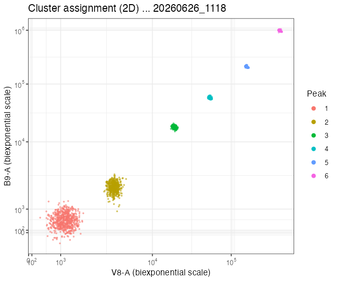

Run 20260626_1118

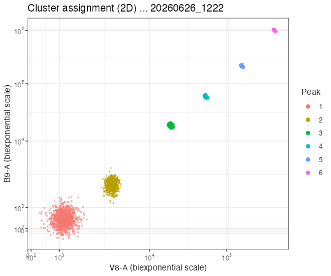

Run 20260626_1222

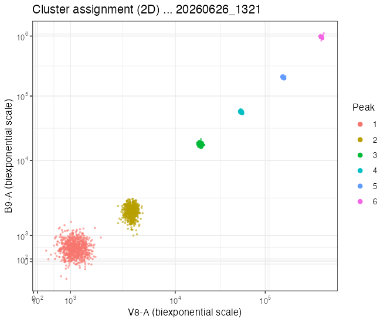

Run 20260626_1321

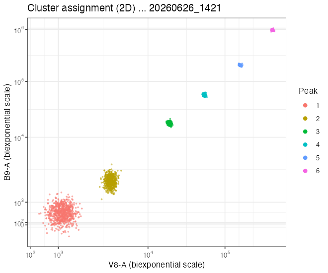

Run 20260626_1421

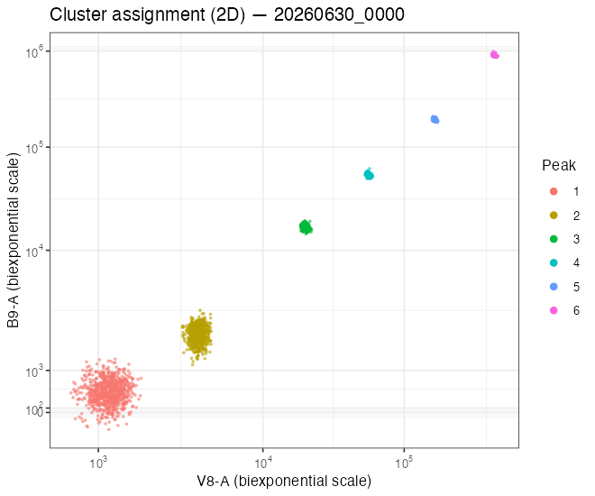

Run 20260630_0000

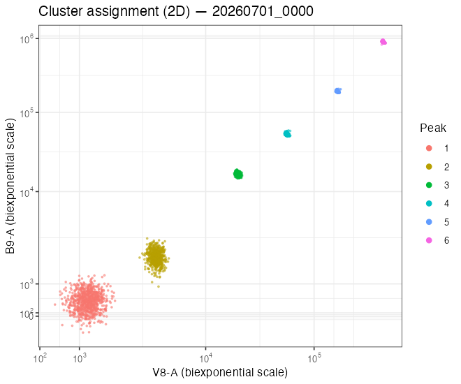

Run 20260701_0000

```r
clus_imgs <- sort(list.files("images/6peak_ultra_evo", pattern = "^cluster2d_.*[.]png$", full.names = TRUE))
if (length(clus_imgs) == 0) cat("_No saved cluster images yet — run `scripts/Process6PeakUltra.R`._\n\n") else {
  cat("::: {layout-ncol=3}\n")
  for (f in clus_imgs) cat(sprintf("![Run %s](../%s)\n\n", sub("^cluster2d_(.*)[.]png$","\\1",basename(f)), f))
  cat(":::\n")
}
```

### Cluster-size sanity

URCP-38-2K mixes the 6 populations in roughly equal proportions (blank particles may be slightly more abundant). Cluster sizes should be broadly even — a quick numeric check that no population was split or merged by the clustering step.

```r
csz <- pm |> group_by(run_label, peak) |>
  summarise(events = mean(n, na.rm = TRUE), .groups = "drop") |>
  mutate(peak = factor(peak, levels = 1:n_peaks))
gp(ggplot(csz, aes(factor(peak), events, fill = run_label,
                   text = sprintf("peak %s | %s<br>mean events %.0f", peak, run_label, events))) +
     geom_col(position = position_dodge()) +
     labs(title = "Cluster size per peak (events per run; peak 1 = blank)",
          x = "Peak", y = "Events", fill = NULL) +
     theme_bw(base_size = 10), 300)
```

[interactive chart not shown]

## Tracking over time

### Per-laser overview

Two 5-laser × run heatmaps of peak-6 deviation from each detector’s baseline (first run), averaged across the laser. **Top:** median intensity shift (blue = dimmer, red = brighter). **Bottom:** %rCV shift (blue = tighter, red = broader). A whole-row shift points to a laser-level issue; an isolated tile flags a single detector.

```r
p6_base <- pm |> filter(peak == n_peaks, in_range) |> group_by(detector) |>
  slice_min(run_label, n = 1, with_ties = FALSE) |>
  transmute(detector, base_median = median) |> ungroup()
laser_delta <- pm |> filter(peak == n_peaks, in_range) |>
  left_join(p6_base, by = "detector") |>
  mutate(delta_pct = (median - base_median) / base_median * 100,
         laser = factor(laser_of(detector), levels = laser_levels)) |>
  group_by(laser, run_label) |> summarise(delta_pct = mean(delta_pct, na.rm = TRUE), .groups = "drop")
lim <- max(abs(laser_delta$delta_pct), na.rm = TRUE); if (!is.finite(lim) || lim == 0) lim <- 1
gp(ggplot(laser_delta, aes(run_label, laser, fill = delta_pct,
        text = sprintf("%s laser | %s<br>%+.1f%% vs baseline", laser, run_label, delta_pct))) +
     geom_tile(colour = "white") +
     scale_y_discrete(limits = rev(laser_levels)) +
     scale_fill_gradient2(low = "#2166ac", mid = "white", high = "#b2182b", midpoint = 0,
                          limits = c(-lim, lim), name = "Peak 6\nΔ median\nvs t0") +
     labs(title = "Per-laser peak-6 median deviation from baseline", x = NULL, y = "Laser") +
     theme_bw(base_size = 11) +
     theme(axis.text = element_text(size = 10)), 420)
```

[interactive chart not shown]

```r
p6_base_cv <- pm |> filter(peak == n_peaks, in_range) |> group_by(detector) |>
  slice_min(run_label, n = 1, with_ties = FALSE) |>
  transmute(detector, base_rcv = rcv) |> ungroup()
laser_delta_cv <- pm |> filter(peak == n_peaks, in_range) |>
  left_join(p6_base_cv, by = "detector") |>
  mutate(delta_pct = (rcv - base_rcv) / base_rcv * 100,
         laser = factor(laser_of(detector), levels = laser_levels)) |>
  group_by(laser, run_label) |> summarise(delta_pct = mean(delta_pct, na.rm = TRUE), .groups = "drop")
lim_cv <- max(abs(laser_delta_cv$delta_pct), na.rm = TRUE); if (!is.finite(lim_cv) || lim_cv == 0) lim_cv <- 1
gp(ggplot(laser_delta_cv, aes(run_label, laser, fill = delta_pct,
        text = sprintf("%s laser | %s<br>%+.1f%% vs baseline rCV", laser, run_label, delta_pct))) +
     geom_tile(colour = "white") +
     scale_y_discrete(limits = rev(laser_levels)) +
     scale_fill_gradient2(low = "#2166ac", mid = "white", high = "#b2182b", midpoint = 0,
                          limits = c(-lim_cv, lim_cv), name = "Peak 6\nΔ %rCV\nvs t0") +
     labs(title = "Per-laser peak-6 %rCV deviation from baseline", x = NULL, y = "Laser") +
     theme_bw(base_size = 11) +
     theme(axis.text = element_text(size = 10)), 420)
```

[interactive chart not shown]

**NotePer-peak median intensity by run**

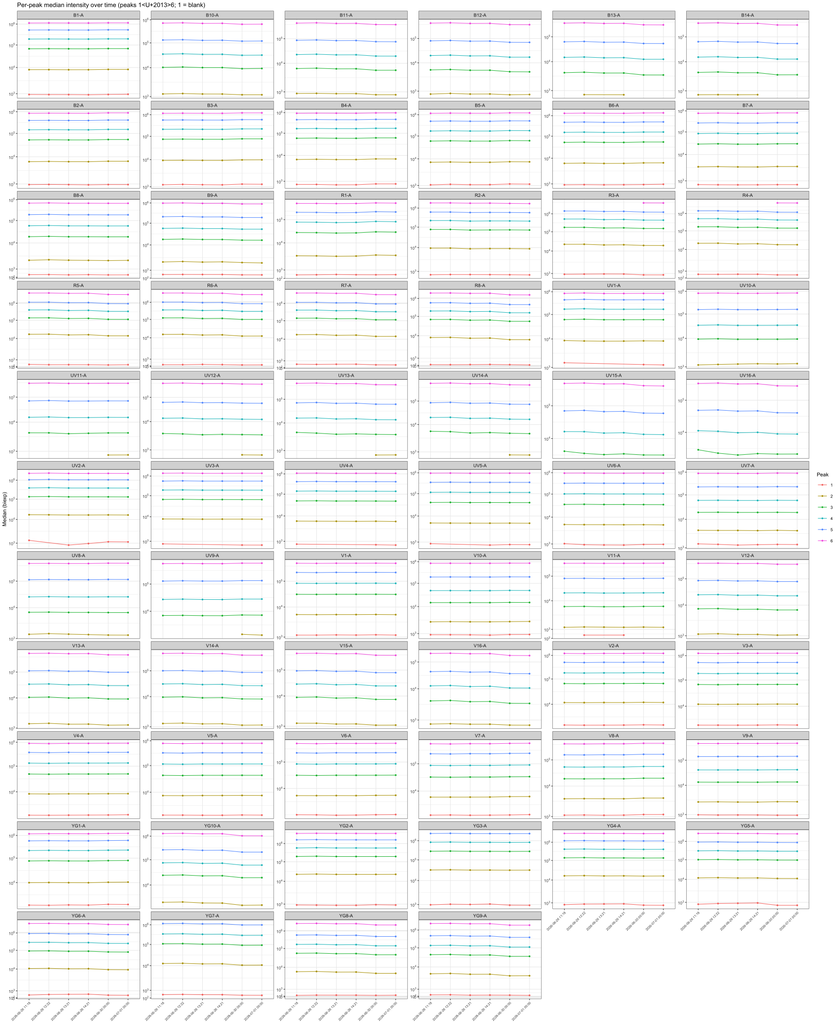

```r
trend <- pm |> filter(resolved, in_range) |> mutate(peak = factor(peak, levels = 1:n_peaks))
ggplot(trend, aes(run_label, median, colour = peak, group = peak)) +
  geom_line() + geom_point(size = 0.8) +
  scale_y_flowjo_biexp(maxValue = biex_max, pos = biex_pos, neg = biex_neg, widthBasis = biex_width_basis) +
  facet_wrap(~ detector, scales = "free_y", ncol = 6) +
  labs(title = "Per-peak median intensity over time (peaks 1–6; 1 = blank)",
       x = NULL, y = "Median (biexp)", colour = "Peak") +
  theme_bw(base_size = 8) +
  theme(strip.text = element_text(size = 7), axis.text.x = element_text(size = 5, angle = 45, hjust = 1))
```

**Note%robust-CV trend**

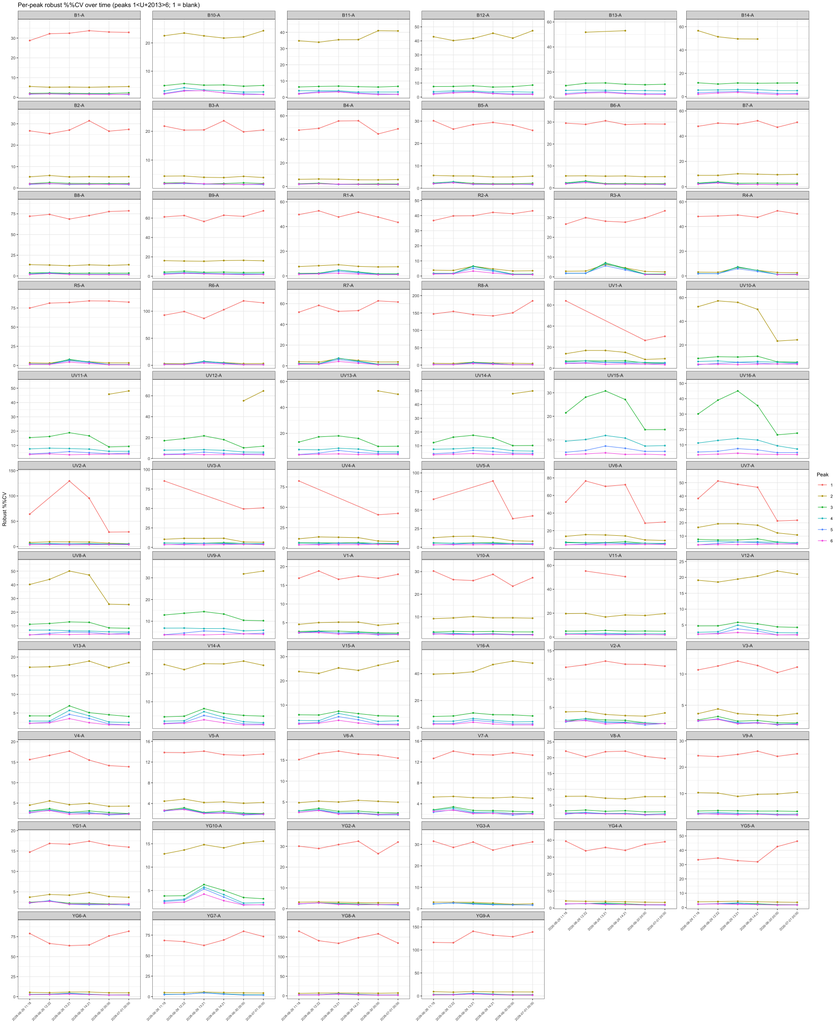

```r
ggplot(trend, aes(run_label, rcv, colour = peak, group = peak)) +
  geom_line() + geom_point(size = 0.8) +
  facet_wrap(~ detector, scales = "free_y", ncol = 6) +
  cv_y_scale +
  labs(title = "Per-peak robust %%CV over time (peaks 1–6; 1 = blank)",
       x = NULL, y = "Robust %%CV", colour = "Peak") +
  theme_bw(base_size = 8) +
  theme(strip.text = element_text(size = 7), axis.text.x = element_text(size = 5, angle = 45, hjust = 1))
```

## Resolution & SI

Number of the 6 populations resolved per detector (0–6) and the staining index (lowest resolved peak vs the blank). Detectors losing dim peaks over time = rising noise floor.

```r
gp(heat(res, "n_resolved", "Peaks resolved (0–6)"))
```

[interactive chart not shown]

```r
gp(heat(si |> filter(is.finite(si)), "si", "Staining index", "absolute; higher = better"))
gp(heat_fc(si |> filter(is.finite(si)), "si", "Staining index — fold-change", "vs its own best; red = degraded", higher_better = TRUE))
```

[interactive chart not shown]

## Staining index

Sensitivity over time: how far the **first resolved peak above the blank** sits above peak 1 (blank particles), relative to the blank’s spread — the classical detector-sensitivity benchmark, $\mathrm{SI} = (\widetilde{m}_{\text{pos}} - \widetilde{m}_1)/(2\,\widetilde{\sigma}_1)$. Point colour marks which peak was used as the positive (it falls back from peak 2 toward peak 6 in weak detectors); a change in that reference for a detector is worth a look. A trend that drops = rising background or falling gain. The cross-detector snapshot is the SI heatmap under **Resolution & SI**.

**NoteSI trend per detector (expand — one panel per detector)**

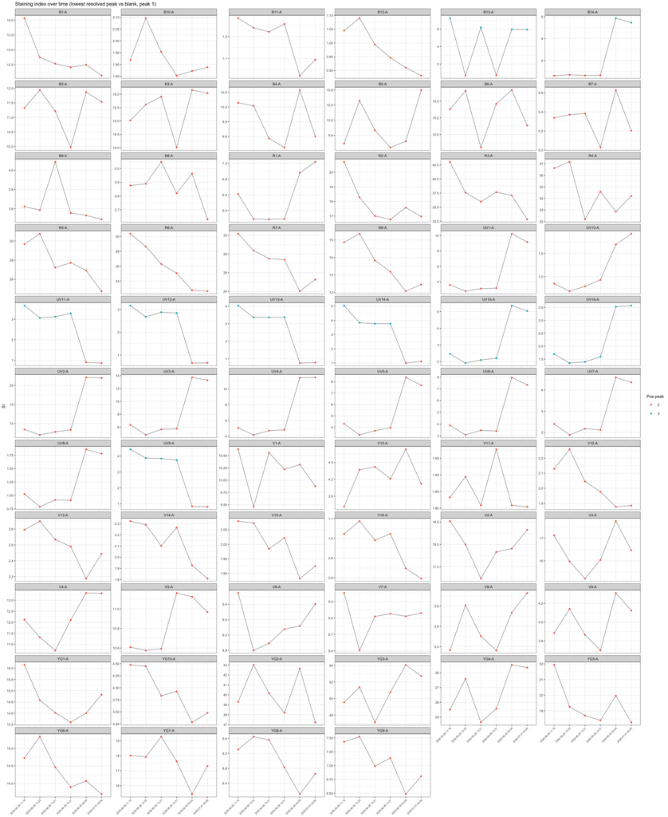

```r
ggplot(si |> filter(!is.na(si)), aes(run_label, si)) +
  geom_line(aes(group = detector), colour = "grey55") +
  geom_point(aes(colour = factor(pos_peak)), size = 1.2) +
  facet_wrap(~ detector, scales = "free_y", ncol = 6) +
  labs(title = "Staining index over time (lowest resolved peak vs blank, peak 1)",
       x = NULL, y = "SI", colour = "Pos peak") +
  theme_bw(base_size = 8) +
  theme(strip.text = element_text(size = 7), axis.text.x = element_text(size = 5, angle = 45, hjust = 1))
```

## %CV & noise floor

Peak 6 (brightest) uses **robust %CV** — it has a well-defined mean (~1–2% when healthy). The blank (peak 1) uses its **absolute robust spread** (IQR/1.349), not %CV: the blank sits near zero, so %CV explodes when the mean dips toward zero even though the actual spread is unchanged. A rising blank spread is a genuine noise-floor increase.

```r
gp(heat(cvtop, "cvt", "Peak-6 %CV", "brightest population (mean well-defined)"))
```

[interactive chart not shown]

```r
gp(heat(cvp1, "sd1", "Peak-1 noise floor", "absolute robust spread (IQR/1.349), not %%CV"))
gp(heat_fc(cvp1, "sd1", "Noise floor — fold-change", "lower is better; red = noisier than its best", higher_better = FALSE))
```

[interactive chart not shown]

```r
cl_lat <- cvtop |> group_by(laser = factor(laser_of(detector), levels = laser_levels), run_label) |>
  summarise(cvt = mean(cvt, na.rm = TRUE), .groups = "drop")
gp(ggplot(cl_lat, aes(run_label, cvt, colour = laser, group = laser)) +
     geom_line() + geom_point() +
     labs(title = "Mean peak-6 %%CV per laser (± control context as runs accumulate)",
          x = NULL, y = "Peak-6 %%CV") + theme_bw(base_size = 10) +
     theme(axis.text.x = element_text(angle = 30, hjust = 1)), 320)
```

[interactive chart not shown]

## Brightest peak (peak 6) %CV

A focused per-detector view of peak 6 (the brightest fluorescent level) alone over time. The brightest population is normally the tightest (~1–2%), so any rise is a sensitive indicator of saturation, noise, or linearity issues at the top of the dynamic range. The cross-detector snapshot and per-laser mean are under **%CV & noise floor**.

**NotePeak-6 %CV trend per detector (expand — one panel per detector)**

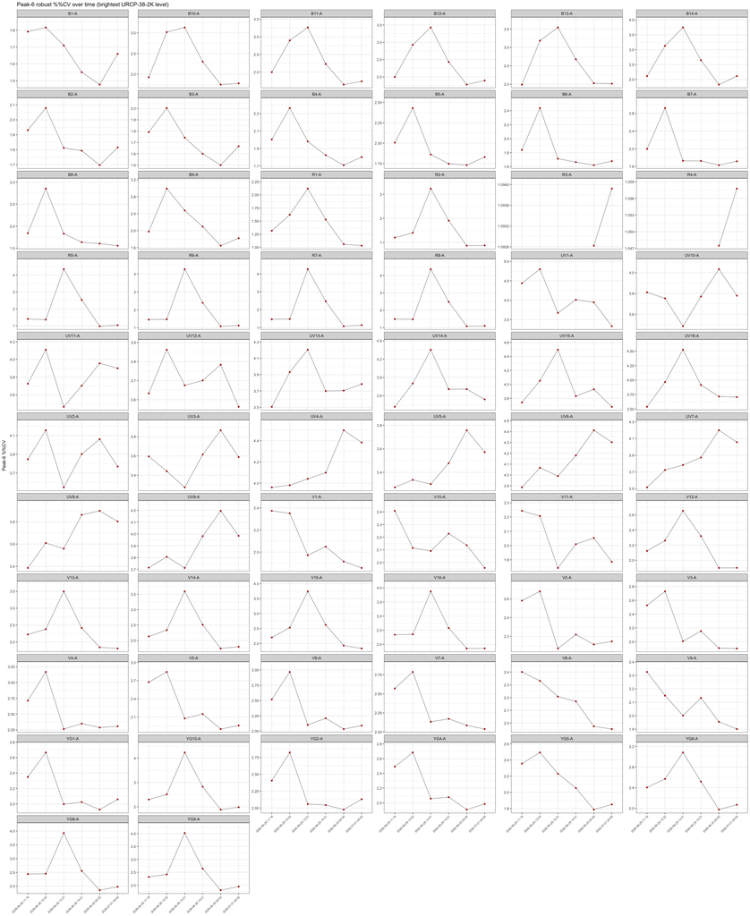

```r
peak6 <- pm |> filter(peak == n_peaks, in_range)
ggplot(peak6, aes(run_label, rcv, group = detector)) +
  geom_line(colour = "grey60") + geom_point(size = 1, colour = "firebrick") +
  facet_wrap(~ detector, scales = "free_y", ncol = 6) +
  cv_y_scale +
  labs(title = "Peak-6 robust %%CV over time (brightest URCP-38-2K level)",
       x = NULL, y = "Peak-6 %%CV") +
  theme_bw(base_size = 8) +
  theme(strip.text = element_text(size = 7), axis.text.x = element_text(size = 5, angle = 45, hjust = 1))
```

## Spectral signature

Cosine similarity of each peak’s normalised 64-detector signature to the baseline run. 1.000 = unchanged; a drop indicates an optical / alignment / filter change that per-detector intensities alone would miss.

```r
sp <- spec |> mutate(peak = factor(peak, levels = 1:n_peaks))
gp(ggplot(sp, aes(run_label, peak, fill = cosine,
                  text = sprintf("peak %s | %s<br>cosine %.4f", peak, run_label, cosine))) +
     geom_tile(colour = "white") +
     scale_fill_viridis_c(option = "magma", limits = c(min(0.99, min(sp$cosine, na.rm=TRUE)), 1)) +
     labs(title = "Spectral-signature similarity to baseline", x = NULL, y = "Peak") +
     theme_bw(base_size = 10) + theme(axis.text.x = element_text(angle = 30, hjust = 1)), 300)
```

[interactive chart not shown]

## Per-run diagnostics

The bead gate saved by `Process6PeakUltra.R` per run — it should land on the dense scatter cluster. (The 2D cluster-assignment diagnostic is in the **Peak clustering** tab.)

### Bead gate (FSC-A × SSC-A)

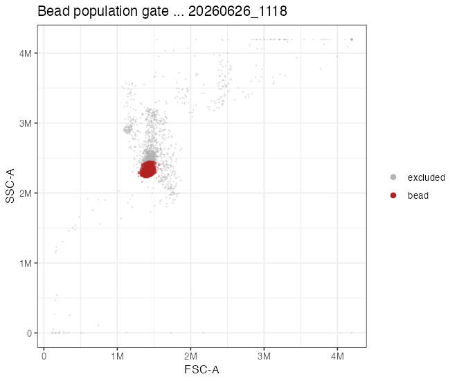

Run 20260626_1118

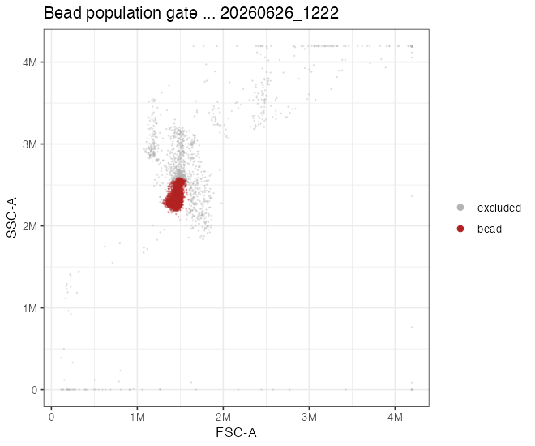

Run 20260626_1222

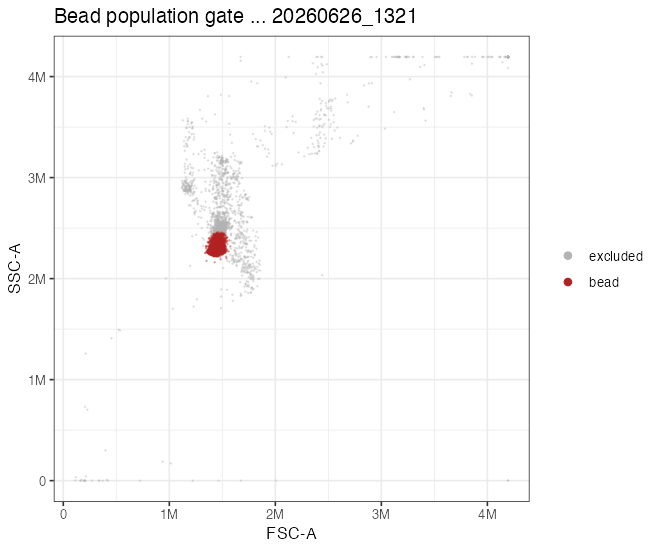

Run 20260626_1321

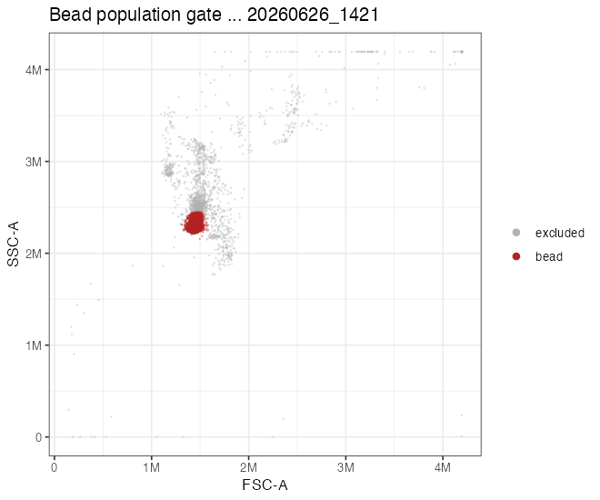

Run 20260626_1421

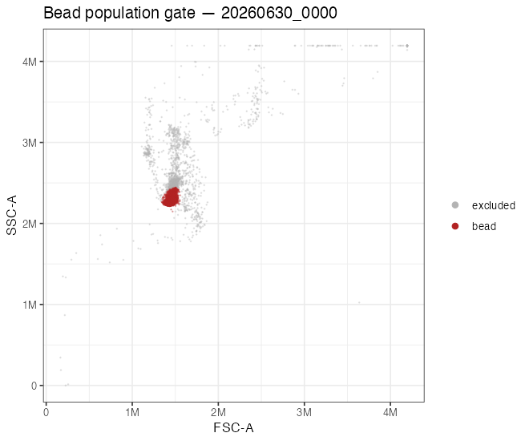

Run 20260630_0000

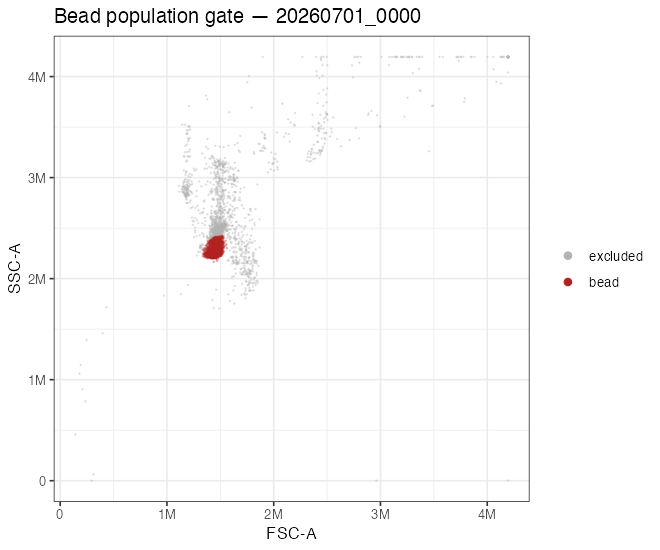

Run 20260701_0000

```r
gate_imgs <- sort(list.files("images/6peak_ultra_evo", pattern = "^gate_.*[.]png$", full.names = TRUE))
if (length(gate_imgs) == 0) cat("_No saved gate images yet — run `scripts/Process6PeakUltra.R`._\n\n") else {
  cat("::: {layout-ncol=3}\n")
  for (f in gate_imgs) cat(sprintf("![Run %s](../%s)\n\n", sub("^gate_(.*)[.]png$","\\1",basename(f)), f))
  cat(":::\n")
}
```

## Sensitivity (Q & B) · in development

**Warning**

**In development.** The Q/B sensitivity model, MEF calibration, linearity, and gain context below are still being validated against the URCP-38-2K bead lot — treat as preliminary, not yet for routine QC decisions.

**Q** = detection efficiency (photoelectrons per unit signal, gain-normalised) — a drop means the detector collects less light per event. **B** = background/noise term; **intrinsic CV** = the high-signal noise floor (bead + optics), **measured** as the brightest resolved peak’s CV. Q and B are estimated per detector from the intrinsic-corrected CV² vs 1/MFI across the resolved peaks. Because `Q = 1/slope` blows up when the slope nears zero, fits that are **ill-conditioned** — near-flat slope, R² < 0.8, a non-monotonic CV profile, or a brightest-peak CV > 15% — are **suppressed** (left blank) rather than reported as a phantom Q spike; the underlying cause then shows in the %CV panel. Separately, runs whose beads fail the **photon-domination** check (dim-peak CV < 2× the bright peak, or dim-peak SD < 3× the blank; Chase 1998) are kept but flagged **advisory** — on spectral rainbow beads many runs fall short of that ideal, so those Q/B are lower-confidence rather than wrong.

**NoteMethod & provenance — read me**

This is the **Q–B detector-sensitivity model** of Hoffman & Wood (Wood JC, *Cytometry* 1998;33:260–266; Wood & Hoffman, *Cytometry* 1998;33:256–259; Chase & Hoffman, *Cytometry* 1998;33:267–279; Hoffman & Wood, *Current Protocols in Cytometry* Unit 1.20, 2007), the same model behind Spherotech’s **STN-17** and BD’s **CS&T Qr/Br**. Total spread decomposes as `CV² = CV_intr² + (1/Q)(1/S) + (B/Q)(1/S²)`. Following Hoffman & Wood, the intrinsic CV is taken directly from the **brightest resolved peak** and subtracted; the intrinsic-corrected CV² is then fit vs 1/S through the origin, giving `1/Q` (linear term) and `B/Q` (curvature).

**The panel-wide values use gain-normalised MFI (`S = MFI/gain`), not MEF, so Q and B are a *relative, non-normalised* index** — valid for **single-detector trend monitoring (Levey-Jennings)**, *not* cross-detector comparison, and expect small steps when a bead lot changes. Absolute, gain-independent sensitivity lives in the **MEF-unit Q/B** and **detection-limit (MEF)** panels below, on the anchor detectors.

**Two method caveats (Hoffman & Wood 2007).** (1) *Linear scale.* The Q/B model assumes photoelectron (Poisson) statistics on a linearly-amplified signal; Aurora MFI and robust CV are taken on the linear scale, which satisfies this — log-amp data would make B in particular unreliable. (2) *Red / far-red detectors.* Hoffman notes dim Rainbow beads can carry too high an intrinsic CV to give valid Q/B on red-laser channels; URCP-38-2K spans a wider range, but the same spectral-mismatch caution applies, so read red / far-red Q/B with extra care.

```r
if (fc_locked) cat(sprintf("> **FC reference: LOCKED** to qualified window %s – %s (per-detector median ± SD).\n",
                           fc_ref_window[1], fc_ref_window[2])) else
  cat(sprintf("> **FC reference: dynamic / preliminary** — each detector vs its own best of %d run(s). Lock a fixed reference once enough qualified runs accumulate.\n", n_runs))
```

> **FC reference: dynamic / preliminary** — each detector vs its own best of 6 run(s). Lock a fixed reference once enough qualified runs accumulate.

```r
gp(heat(qb, "Q", "Detection efficiency Q", "absolute — gain-normalised; higher = better"))
gp(heat_fc(qb, "Q", "Q — fold-change (per detector)", "vs its own best; red = degraded", higher_better = TRUE))
```

[interactive chart not shown]

**Background B/Q (relative).** The relative fit reports the raw `I(inv²)` coefficient, which is **B/Q**, not B — a change here can be driven by background *or* by efficiency. The canonical, blank-derived **B** in true MEF units is in the STN-17 panel below (Chase & Hoffman 1998). Shown absolute only: this coefficient can be ≤ 0, so a fold-change vs best is undefined for it.

```r
gp(heat(qb |> filter(is.finite(B)), "B", "Background B/Q (relative)", "curvature coefficient — not blank-derived B; higher = more background/noise"))
```

[interactive chart not shown]

```r
flagged <- qb |> filter(!is.na(qflag), qflag != "n<3")
if (nrow(flagged)) {
  fl <- flagged |> group_by(run_label) |>
    summarise(`detectors suppressed` = n(),
              `example reasons` = paste(head(sort(unique(qflag)), 3), collapse = " | "),
              .groups = "drop")
  knitr::kable(fl, caption = "SUPPRESSED (blank tiles above): detector-runs where the Q/B fit was ill-conditioned — NOT a sensitivity gain. The cause appears in the %CV & noise-floor panel.")
}
```

SUPPRESSED (blank tiles above): detector-runs where the Q/B fit was ill-conditioned — NOT a sensitivity gain. The cause appears in the %CV & noise-floor panel.

| run_label | detectors suppressed | example reasons |
| --- | --- | --- |
| 2026-06-26 11:18 | 2 | non-monotonic |
| 2026-06-26 12:22 | 1 | non-monotonic |
| 2026-06-26 13:21 | 9 | R2=0.00 \| R2=0.01 \| R2=0.06 |
| 2026-06-26 14:21 | 7 | R2=0.33 \| R2=0.39 \| R2=0.50 |
| 2026-07-01 00:00 | 4 | R2=0.62 \| non-monotonic |

```r
advised <- qb |> filter(is.finite(Q), !is.na(qadv))
if (nrow(advised)) {
  av <- advised |> group_by(run_label) |>
    summarise(`detectors advised` = n(), .groups = "drop")
  knitr::kable(av, caption = "ADVISORY (Q/B still shown, lower-confidence): detector-runs whose beads did not meet the photon-domination criteria (Chase 1998, intrinsic-corrected: dim-peak CV < 2x the bright peak, or dim-peak SD < 3x the blank). Common for spectral rainbow beads, so treat these Q/B as indicative, not absolute.")
}
```

ADVISORY (Q/B still shown, lower-confidence): detector-runs whose beads did not meet the photon-domination criteria (Chase 1998, intrinsic-corrected: dim-peak CV < 2x the bright peak, or dim-peak SD < 3x the blank). Common for spectral rainbow beads, so treat these Q/B as indicative, not absolute.

| run_label | detectors advised |
| --- | --- |
| 2026-06-26 11:18 | 62 |
| 2026-06-26 12:22 | 57 |
| 2026-06-26 13:21 | 49 |
| 2026-06-26 14:21 | 51 |
| 2026-06-30 00:00 | 64 |
| 2026-07-01 00:00 | 60 |

```r
# Relative Q is in arbitrary per-detector units, so a median of ABSOLUTE Q across
# detectors mixes incommensurable scales (BD/Chase: relative Q is single-detector
# only). Aggregate the per-detector % change from baseline instead — a percentage
# IS comparable across detectors (BD: a 50% change is a 50% change in any units).
ql <- metrics |> filter(is.finite(Q_d)) |>
  mutate(laser = factor(laser_of(detector), levels = laser_levels)) |>
  group_by(laser, run_label) |> summarise(Qd = median(Q_d, na.rm = TRUE), .groups = "drop")
gp(ggplot(ql, aes(run_label, Qd, colour = laser, group = laser,
                  text = sprintf("%s laser | %s<br>median ΔQ %.1f%% vs baseline", laser, run_label, Qd))) +
     geom_line() + geom_point() + geom_hline(yintercept = 0, linetype = "dashed", colour = "grey60") +
     labs(title = "Median Q change from baseline per laser", x = NULL, y = "Q change vs baseline (%)") +
     theme_bw(base_size = 10) + theme(axis.text.x = element_text(angle = 30, hjust = 1)), 320)
```

[interactive chart not shown]

True sensitivity in standardized units — the **detection limit (MEF)** per anchor detector from the URCP-38-2K calibration. Gain-independent, so a rise is a real sensitivity loss (not the QC gain loop).

```r
gp(ggplot(sens, aes(run_label, MEF_LOD, colour = detector, group = detector,
                    text = sprintf("%s (%s)<br>%s<br>MEF LOD %.0f", detector, fluor, run_label, MEF_LOD))) +
     geom_line() + geom_point() + scale_y_log10() +
     labs(title = "Detection limit (MEF) per anchor detector — URCP-38-2K",
          x = NULL, y = "MEF at detection threshold (log)") +
     theme_bw(base_size = 10) + theme(axis.text.x = element_text(angle = 30, hjust = 1)), 340)
```

[interactive chart not shown]

### Q & B in MEF units (anchor detectors)

```r
gp(ggplot(qb_mef, aes(run_label, Q, colour = detector, group = detector,
        text = sprintf("%s (%s)<br>%s<br>Q(MEF) %.3g | B(MEF) %.3g | intrinsic CV %.2f%%",
                       detector, fluor, run_label, Q, B, 100 * intr_cv))) +
     geom_line() + geom_point() + scale_y_log10() +
     labs(title = "Detection efficiency Q in MEF units — anchor detectors (STN-17)",
          x = NULL, y = "Q (MEF units, log)") +
     theme_bw(base_size = 10) + theme(axis.text.x = element_text(angle = 30, hjust = 1)), 340)
```

[interactive chart not shown]

```r
latest_mef <- max(qb_mef$run_label)
cmp <- qb_mef |> filter(run_label == latest_mef) |>
  transmute(Detector = detector, Fluor = fluor,
            `Q (MEF)` = signif(Q, 3), `B (MEF)` = signif(B, 3),
            `intrinsic CV %` = round(100 * intr_cv, 2)) |>
  left_join(qb |> mutate(detector = as.character(detector)) |> filter(run_label == latest_mef) |>
              transmute(Detector = detector, `Q (relative)` = signif(Q, 3)),
            by = "Detector")
knitr::kable(cmp, caption = sprintf(
  "Anchor-detector sensitivity, run %s. Intrinsic CV is the measured brightest-peak CV (common to both fits). Q (MEF) is the absolute, gain-independent value; Q (relative) the gain-normalised one — the two Q columns should co-track.", latest_mef))
```

Anchor-detector sensitivity, run 2026-07-01 00:00. Intrinsic CV is the measured brightest-peak CV (common to both fits). Q (MEF) is the absolute, gain-independent value; Q (relative) the gain-normalised one — the two Q columns should co-track.

| Detector | Fluor | Q (MEF) | B (MEF) | intrinsic CV % | Q (relative) |
| --- | --- | --- | --- | --- | --- |
| B2-A | FITC | 0.1540 | 3770 | 1.82 | 38.9 |
| B9-A | PerCP-Cy5.5 | 0.3720 | 2100 | 1.82 | 30.7 |
| R1-A | APC | 0.7120 | 3150 | 1.03 | 20.2 |
| R4-A | Alexa700 | 0.3330 | -2250 | 1.06 | 23.2 |
| R7-A | APC-Cy7 | 0.6710 | -58 | 1.14 | 19.5 |
| UV14-A | BUV737 | 0.1830 | 821 | 3.54 | 13.5 |
| UV2-A | BUV395 | NA | NA | 3.77 | NA |
| V1-A | BV421 | 1.8100 | 851 | 1.86 | 30.4 |
| V10-A | BV605 | 0.6380 | 4470 | 1.96 | 36.3 |
| V11-A | BV650 | 0.3770 | 5520 | 1.89 | 28.1 |
| V13-A | BV711 | 0.4840 | 5180 | 1.81 | 21.5 |
| V15-A | BV786 | 0.2200 | 4040 | 1.83 | 22.1 |
| V5-A | BV510 | 1.2600 | 2450 | 1.96 | 32.6 |
| YG1-A | PE | NA | NA | 2.06 | NA |
| YG3-A | PE-TexasRed(561) | 0.7410 | 6250 | 1.76 | 30.2 |
| YG5-A | PE-Cy5(561) | 0.0756 | 180 | 1.85 | 30.0 |
| YG6-A | PE-Cy5.5 | 0.1550 | 8220 | 2.07 | 24.5 |
| YG9-A | PE-Cy7 | 0.2370 | 10300 | 1.95 | 19.8 |

The regression above uses the resolved fluorescent peaks (the blank is used only as the blank). As an independent check, the **literal STN-17 closed form** uses just three populations — the blank (**Dim Bead 1 = peak 1**), one **dim bead**, and the **brightest**. Both the dim and bright beads are **per-detector**: the dim bead is the *lowest fluorescent population resolved from the blank* and the bright bead is the *highest resolved in-range population* on that detector (not a fixed peak 6, which may be saturated) — so they vary detector-to-detector (see the **Dim peak** / **Top peak** columns) and the bright bead matches the high-signal floor the regression uses. The blank carries no assigned MEF, so it is **extrapolated through the per-run calibration**, then `Q = 1/(CV²_blank × MEF_blank)`. The two Q estimates won’t match exactly (3-point algebra vs. multi-point fit) but should track each other; large divergence flags a nonlinear detector.

```r
stn_tab <- stn17 |> filter(run_label == latest_mef) |>
  transmute(Detector = detector, Fluor = fluor,
            `MFI blank` = signif(m1, 3), `MEF blank (extrap.)` = signif(MEF_blank, 3),
            `CV% blank` = round(100 * cv1, 1), `Dim peak` = dimpeak, `Top peak` = toppeak,
            `Q (STN-17)` = signif(Q_stn, 3), `B (STN-17)` = signif(B_stn, 3)) |>
  left_join(qb_mef |> filter(run_label == latest_mef) |>
              transmute(Detector = detector, `Q (MEF regr.)` = signif(Q, 3)),
            by = "Detector")
knitr::kable(stn_tab, caption = sprintf(
  "STN-17 closed form, run %s. MEF blank is extrapolated through the per-run calibration; Q (STN-17) is 1/(CV²_blank × MEF_blank), beside the multi-point regression Q. Ill-conditioned rows (blank/dim peak not broader than the bright peak, e.g. a noisy-laser run) are shown as NA rather than a negative value.", latest_mef))
```

STN-17 closed form, run 2026-07-01 00:00. MEF blank is extrapolated through the per-run calibration; Q (STN-17) is 1/(CV²_blank × MEF_blank), beside the multi-point regression Q. Ill-conditioned rows (blank/dim peak not broader than the bright peak, e.g. a noisy-laser run) are shown as NA rather than a negative value.

| Detector | Fluor | MFI blank | MEF blank (extrap.) | CV% blank | Dim peak | Top peak | Q (STN-17) | B (STN-17) | Q (MEF regr.) |
| --- | --- | --- | --- | --- | --- | --- | --- | --- | --- |
| B2-A | FITC | 928.0 | 489.0 | 27.4 | 2 | 6 | 0.02730 | 271.00 | 0.1540 |
| B9-A | PerCP-Cy5.5 | 457.0 | 158.0 | 67.5 | 2 | 6 | 0.01390 | 302.00 | 0.3720 |
| R1-A | APC | 486.0 | 158.0 | 43.4 | 2 | 6 | 0.03370 | 144.00 | 0.7120 |
| R4-A | Alexa700 | 488.0 | 143.0 | 50.3 | 2 | 6 | 0.02760 | 52.70 | 0.3330 |
| R7-A | APC-Cy7 | 435.0 | 38.9 | 61.6 | 2 | 6 | 0.06780 | 13.20 | 0.6710 |
| UV14-A | BUV737 | 85.7 | 32.6 | 300.2 | 2 | 6 | 0.00340 | 55.90 | 0.1830 |
| UV2-A | BUV395 | 1170.0 | 100.0 | 29.1 | 2 | 6 | 0.11800 | 92.30 | NA |
| V1-A | BV421 | 1210.0 | 145.0 | 17.9 | 2 | 6 | 0.21400 | 184.00 | 1.8100 |
| V10-A | BV605 | 897.0 | 366.0 | 27.3 | 2 | 6 | 0.03670 | 543.00 | 0.6380 |
| V11-A | BV650 | 397.0 | 319.0 | 58.4 | 3 | 6 | 0.00920 | 802.00 | 0.3770 |
| V13-A | BV711 | 178.0 | 126.0 | 134.5 | 2 | 6 | 0.00438 | 324.00 | 0.4840 |
| V15-A | BV786 | 158.0 | 125.0 | 159.0 | 2 | 6 | 0.00315 | 200.00 | 0.2200 |
| V5-A | BV510 | 1960.0 | 330.0 | 13.5 | 2 | 6 | 0.16500 | 370.00 | 1.2600 |
| YG1-A | PE | 1820.0 | 491.0 | 15.9 | 2 | 6 | 0.08030 | 401.00 | NA |
| YG3-A | PE-TexasRed(561) | 908.0 | 184.0 | 31.1 | 2 | 5 | 0.05610 | 70.40 | 0.7410 |
| YG5-A | PE-Cy5(561) | 616.0 | 360.0 | 46.3 | 2 | 6 | 0.01300 | 56.20 | 0.0756 |
| YG6-A | PE-Cy5.5 | 396.0 | 469.0 | 81.7 | 2 | 6 | 0.00320 | 1220.00 | 0.1550 |
| YG9-A | PE-Cy7 | 204.0 | 42.3 | 139.1 | 3 | 6 | 0.01220 | 2.29 | 0.2370 |

### Linearity

**MEF-calibrated** (SPHERO URCP-38-2K) for the 18 anchor detectors, plus a rank-based R² overview for all 64. On the log–log fit a slope ≠ 1 or curvature flags APD compression/saturation (bright end) or floor effects (dim end). The certificate’s 5 fluorescent peaks map directly to data peaks 2–6 (peak 1 = blank, unassigned).

```r
ld <- lin_mef |> filter(run_label == max(run_label)) |> mutate(panel = paste0(fluor, " (", detector, ")"))
gp(ggplot(ld, aes(MEF, median)) +
     geom_smooth(method = "lm", se = FALSE, colour = "grey65", linewidth = 0.4) +
     geom_point(aes(text = sprintf("data peak %s<br>MEF %.0f<br>MFI %.0f", peak, MEF, median)), size = 1.3) +
     scale_x_log10() + scale_y_log10() +
     facet_wrap(~ panel, scales = "free", ncol = 3) +
     labs(title = sprintf("MEF-calibrated linearity — %s", max(lin_mef$run_label)),
          x = "Assigned MEF (URCP-38-2K)", y = "Measured MFI") +
     theme_bw(base_size = 8), 600)
```

[interactive chart not shown]

```r
sens |> group_by(detector) |> arrange(run_label) |>
  summarise(Fluorophore = dplyr::first(fluor),
            `slope (~1)` = round(dplyr::last(b), 2),
            `R2` = round(dplyr::last(r2), 4),
            `MEF LOD` = round(dplyr::last(MEF_LOD)),
            `LOD d%% vs base` = round((dplyr::last(MEF_LOD) - dplyr::first(MEF_LOD)) / dplyr::first(MEF_LOD) * 100, 1),
            .groups = "drop") |>
  arrange(match(detector, detector_channels)) |>
  knitr::kable(caption = "Per-anchor linearity & detection limit (latest run). MEF LOD = smallest distinguishable equivalent-fluorophore amount (gain-independent); lower = more sensitive.")
```

Per-anchor linearity & detection limit (latest run). MEF LOD = smallest distinguishable equivalent-fluorophore amount (gain-independent); lower = more sensitive.

| detector | Fluorophore | slope (~1) | R2 | MEF LOD | LOD d%% vs base |
| --- | --- | --- | --- | --- | --- |
| UV2-A | BUV395 | 1.36 | 1.0000 | 140 | -31.3 |
| UV14-A | BUV737 | 1.31 | 0.9998 | 145 | -39.0 |
| V1-A | BV421 | 1.20 | 0.9999 | 187 | 2.3 |
| V5-A | BV510 | 1.15 | 0.9999 | 406 | -0.9 |
| V10-A | BV605 | 1.36 | 0.9998 | 505 | -2.4 |
| V11-A | BV650 | 1.32 | 0.9999 | 572 | -0.1 |
| V13-A | BV711 | 1.33 | 1.0000 | 338 | 3.7 |
| V15-A | BV786 | 1.31 | 1.0000 | 372 | 3.4 |
| B2-A | FITC | 0.98 | 0.9995 | 765 | -2.8 |
| B9-A | PerCP-Cy5.5 | 1.29 | 0.9993 | 307 | 3.6 |
| YG1-A | PE | 0.99 | 1.0000 | 649 | 2.6 |
| YG3-A | PE-TexasRed(561) | 1.00 | 0.9999 | 298 | -5.1 |
| YG5-A | PE-Cy5(561) | 0.79 | 0.9994 | 829 | 1.3 |
| YG6-A | PE-Cy5.5 | 1.28 | 1.0000 | 1000 | 4.4 |
| YG9-A | PE-Cy7 | 0.89 | 1.0000 | 190 | 5.0 |
| R1-A | APC | 1.10 | 0.9996 | 278 | -5.0 |
| R4-A | Alexa700 | 1.00 | 1.0000 | 287 | 6.3 |
| R7-A | APC-Cy7 | 1.02 | 0.9999 | 85 | 8.6 |

#### Rank-based overview (all detectors)

```r
gp(heat(lin, "r2", "Linearity R² (log MFI vs peak rank)", "1 = perfectly log-linear"))
```

[interactive chart not shown]

### Gain context

The daily-QC **gain** applied on each run (rising = APD/laser aging) and **MFI/gain** (gain-removed bead intensity; should be flat if the bead + optics are stable).

```r
if (length(runs_no_gain)) cat(sprintf(
  "::: {.callout-warning appearance='simple'}\nNo daily-QC gain found in the archive for **%s** — these run(s) are shown blank on every gain-normalised panel (relative Q/B, MFI/gain, and the executive overview's Q & MFI rows) rather than mixed onto a raw-MFI scale. Their **gain-independent** metrics (MEF-unit Q/B, linearity, detection limit, resolution, %%CV, spectral signature) are unaffected and fully valid. Update `data/EVO/Archive/ArchivedDataEVO.csv` with the run's gain to populate the gain panels.\n:::\n\n",
  paste(runs_no_gain, collapse = ", ")))
```

```r
gtab <- pm |> filter(peak == n_peaks) |> distinct(run_label, detector, gain)
gp(heat(gtab, "gain", "Applied gain (peak-6 row)", "from daily QC"))
```

[interactive chart not shown]

```r
gp(heat(ptop, "mfi_norm", "Peak-6 MFI / gain", "absolute — gain-removed intensity"))
gp(heat_fc(ptop, "mfi_norm", "MFI/gain — fold-change", "vs its own best; red = dimmer", higher_better = TRUE))
```

[interactive chart not shown]

```r
cat("_No matching daily-QC gain found for these runs (data/EVO/Archive/ArchivedDataEVO.csv) — gain context unavailable, so Q/B and MFI use raw MFI._\n")
```